# Data Science and Business Analytics

# Project 5 - Ensemble Techniques: EasyVisa

# Jorge Ramon Vazquez Campero

[figure not shown]

### Problem Statement

- - Business Context
  - Objective
  - Data Description

### Initial Setup

- - Importing Necessary Libraries
  - Data Overview & Sanity Checks

### Exploratory Data Analysis (EDA)

- - Leading questions
  - Answers
    - Question 1
    - Question 2
    - Question 3
    - Question 4
    - Question 5

### Data Preprocessing

- - Missing Value Treatment
  - Outlier Detections and Treatment
  - Feature Engineering
  - Data Preparation for Modeling

### Model Building

- - Model Criterion
  - Decision Tree Model Building
  - Decision Tree - Hyperparameter Tuning
  - Bagging Classifier Model Building
  - Bagging Classifier - Hyperparameter Tuning
  - Random Forest Model Building
  - Random Forest - Hyperparameter Tuning
  - Bagging Model Performance Comparison
  - AdaBoosting - Model Building
  - AdaBoosting - Hyperparameter Tuning
  - Gradient Boosting - Model Building
  - Gradient Boosting - Hyperparameter Tuning
  - XGBoost - Model Building
  - XGBoost - Hyperparameter Tuning
  - Boosting Model Performance Comparison

### Model Performance Comparison and Conclusions

### Will tuning the hyperparameters help?

### Actionable Insights & Recommendations

### Appendix

- - Univariate Analysis
  - Multivariate Analysis

## Problem Statement

### Business Context:

Business communities in the United States are facing high demand for human resources, but one of the constant challenges is identifying and attracting the right talent, which is perhaps the most important element in remaining competitive. Companies in the United States look for hard-working, talented, and qualified individuals both locally as well as abroad.

The Immigration and Nationality Act (INA) of the US permits foreign workers to come to the United States to work on either a temporary or permanent basis. The act also protects US workers against adverse impacts on their wages or working conditions by ensuring US employers' compliance with statutory requirements when they hire foreign workers to fill workforce shortages. The immigration programs are administered by the Office of Foreign Labor Certification (OFLC).

OFLC processes job certification applications for employers seeking to bring foreign workers into the United States and grants certifications in those cases where employers can demonstrate that there are not sufficient US workers available to perform the work at wages that meet or exceed the wage paid for the occupation in the area of intended employment.

### Objective:

In FY 2016, the OFLC processed 775,979 employer applications for 1,699,957 positions for temporary and permanent labor certifications. This was a nine percent increase in the overall number of processed applications from the previous year. The process of reviewing every case is becoming a tedious task as the number of applicants is increasing every year.

The increasing number of applicants every year calls for a Machine Learning based solution that can help in shortlisting the candidates having higher chances of VISA approval. OFLC has hired your firm EasyVisa for data-driven solutions. You as a data scientist have to analyze the data provided and, with the help of a classification model:

- Facilitate the process of visa approvals.
- Recommend a suitable profile for the applicants for whom the visa should be certified or denied based on the drivers that significantly influence the case status.

### Data Description

The data contains the different attributes of the employee and the employer. The detailed data dictionary is given below.

- `case_id`: ID of each visa application
- `continent`: Information of continent the employee
- `education_of_employee`: Information of education of the employee
- `has_job_experience`: Does the employee has any job experience? Y= Yes; N = No
- `requires_job_training`: Does the employee require any job training? Y = Yes; N = No
- `no_of_employees`: Number of employees in the employer's company
- `yr_of_estab`: Year in which the employer's company was established
- `region_of_employment`: Information of foreign worker's intended region of employment in the US.
- `prevailing_wage`: Average wage paid to similarly employed workers in a specific occupation in the area of intended employment. The purpose of the prevailing wage is to ensure that the foreign worker is not underpaid compared to other workers offering the same or similar service in the same area of employment.
- `unit_of_wage`: Unit of prevailing wage. Values include Hourly, Weekly, Monthly, and Yearly.
- `full_time_position`: Is the position of work full-time? Y = Full Time Position; N = Part Time Position
- `case_status`: Flag indicating if the Visa was certified or denied

## Initial Setup

### Importing necessary libraries and data

```python
# Installing the libraries with the specified version.
!pip install numpy==1.25.2 pandas==1.5.3 scikit-learn==1.2.2 matplotlib==3.7.1 seaborn==0.13.1 xgboost==2.0.3
```

**Note**: *After running the above cell, kindly restart the notebook kernel and run all cells sequentially from the start again.*

```python
# Import libraries for data manipulation
import numpy as np
import pandas as pd

# Import libraries for data visualization
import matplotlib.pyplot as plt
import seaborn as sns
import plotly.express as px

# Set default Seaborn theme for plots
sns.set()

# Suppress warnings to prevent them from being displayed during code execution
import warnings
warnings.filterwarnings('ignore')

# Enable the inline plotting of matplotlib figures directly within the notebook
%matplotlib inline

# Set the display format for float values to three decimal places
pd.set_option('display.float_format', lambda x: '%.3f' % x)

# Removes the limit for the number of displayed columns
pd.set_option("display.max_columns", None)
# Sets the limit for the number of displayed rows
pd.set_option("display.max_rows", 100)

# Distribution Libraries for statistical tests
import scipy.stats as stats
from scipy.stats import norm, uniform, binom, expon, t
from scipy.stats import ttest_1samp, ttest_ind

# Libraries for model building and evaluation
import statsmodels.api as sm
from sklearn.model_selection import train_test_split, GridSearchCV
from sklearn.linear_model import LogisticRegression, LinearRegression

# Libraries to get different metric scores
from sklearn import metrics
from sklearn.metrics import (
    confusion_matrix,
    accuracy_score,
    precision_score,
    recall_score,
    f1_score,
)

# Libraries different ensemble classifiers
from sklearn.ensemble import (
    BaggingClassifier,
    RandomForestClassifier,
    AdaBoostClassifier,
    GradientBoostingClassifier,
    StackingClassifier,
)

from xgboost import XGBClassifier
from sklearn.tree import DecisionTreeClassifier, DecisionTreeRegressor
```

### Data Overview & Sanity Checks

- Observations
- Sanity checks

```python
# Load the dataset
data = pd.read_csv("EasyVisa.csv")

# Copying data to another variable to avoid any changes to original data
df = data.copy()
```

```python
# Display the first few rows of the dataset
print("First few rows of the dataset:")
display(df.head())

# Display the last few rows of the dataset
print("Last few rows of the dataset:")
display(df.tail())
```

```
First few rows of the dataset:
```

|  | case_id | continent | education_of_employee | has_job_experience | requires_job_training | no_of_employees | yr_of_estab | region_of_employment | prevailing_wage | unit_of_wage | full_time_position | case_status |
| --- | --- | --- | --- | --- | --- | --- | --- | --- | --- | --- | --- | --- |
| 0 | EZYV01 | Asia | High School | N | N | 14513 | 2007 | West | 592.203 | Hour | Y | Denied |
| 1 | EZYV02 | Asia | Master's | Y | N | 2412 | 2002 | Northeast | 83425.650 | Year | Y | Certified |
| 2 | EZYV03 | Asia | Bachelor's | N | Y | 44444 | 2008 | West | 122996.860 | Year | Y | Denied |
| 3 | EZYV04 | Asia | Bachelor's | N | N | 98 | 1897 | West | 83434.030 | Year | Y | Denied |
| 4 | EZYV05 | Africa | Master's | Y | N | 1082 | 2005 | South | 149907.390 | Year | Y | Certified |

```
Last few rows of the dataset:
```

|  | case_id | continent | education_of_employee | has_job_experience | requires_job_training | no_of_employees | yr_of_estab | region_of_employment | prevailing_wage | unit_of_wage | full_time_position | case_status |
| --- | --- | --- | --- | --- | --- | --- | --- | --- | --- | --- | --- | --- |
| 25475 | EZYV25476 | Asia | Bachelor's | Y | Y | 2601 | 2008 | South | 77092.570 | Year | Y | Certified |
| 25476 | EZYV25477 | Asia | High School | Y | N | 3274 | 2006 | Northeast | 279174.790 | Year | Y | Certified |
| 25477 | EZYV25478 | Asia | Master's | Y | N | 1121 | 1910 | South | 146298.850 | Year | N | Certified |
| 25478 | EZYV25479 | Asia | Master's | Y | Y | 1918 | 1887 | West | 86154.770 | Year | Y | Certified |
| 25479 | EZYV25480 | Asia | Bachelor's | Y | N | 3195 | 1960 | Midwest | 70876.910 | Year | Y | Certified |

- The data look pretty standard. Already can make some observations and we have some binary variables and a case ID that we may need to drop eventually.
- Other than that, based on the head and tail, the data looks pretty clean.

```python
# Display the shape of the dataset
df.shape
print("There are", df.shape[0], "rows and", df.shape[1], "columns.\n")

# Display the data types of the columns in the dataset
df.info()
```

```
There are 25480 rows and 12 columns.

<class 'pandas.core.frame.DataFrame'>
RangeIndex: 25480 entries, 0 to 25479
Data columns (total 12 columns):
 #   Column                 Non-Null Count  Dtype
---  ------                 --------------  -----
 0   case_id                25480 non-null  object
 1   continent              25480 non-null  object
 2   education_of_employee  25480 non-null  object
 3   has_job_experience     25480 non-null  object
 4   requires_job_training  25480 non-null  object
 5   no_of_employees        25480 non-null  int64
 6   yr_of_estab            25480 non-null  int64
 7   region_of_employment   25480 non-null  object
 8   prevailing_wage        25480 non-null  float64
 9   unit_of_wage           25480 non-null  object
 10  full_time_position     25480 non-null  object
 11  case_status            25480 non-null  object
dtypes: float64(1), int64(2), object(9)
memory usage: 2.3+ MB
```

- Again, we can see the data does not show missing values, a case id that we will need to drop and it matches up with the variables in the project description.
- Overall, the data looks pretty clean.

```python
# Display the statistical summary for Numerical variables in the dataset
print("Display the statistical summary for Numerical variables in the dataset:")
display(df.describe().T)

# Display the statistical summary for Categorical variables in the dataset
print("Display the statistical summary for Categorical variables in the dataset:")
display(df.describe(include=["object", "category"]).T)


# Display the complete statistical summary for the dataset
print("Display the complete statistical summary for the dataset:")
display(df.describe(include="all").T)
```

```
Display the statistical summary for Numerical variables in the dataset:
```

|  | count | mean | std | min | 25% | 50% | 75% | max |
| --- | --- | --- | --- | --- | --- | --- | --- | --- |
| no_of_employees | 25480.000 | 5667.043 | 22877.929 | -26.000 | 1022.000 | 2109.000 | 3504.000 | 602069.000 |
| yr_of_estab | 25480.000 | 1979.410 | 42.367 | 1800.000 | 1976.000 | 1997.000 | 2005.000 | 2016.000 |
| prevailing_wage | 25480.000 | 74455.815 | 52815.942 | 2.137 | 34015.480 | 70308.210 | 107735.513 | 319210.270 |

```
Display the statistical summary for Categorical variables in the dataset:
```

|  | count | unique | top | freq |
| --- | --- | --- | --- | --- |
| case_id | 25480 | 25480 | EZYV01 | 1 |
| continent | 25480 | 6 | Asia | 16861 |
| education_of_employee | 25480 | 4 | Bachelor's | 10234 |
| has_job_experience | 25480 | 2 | Y | 14802 |
| requires_job_training | 25480 | 2 | N | 22525 |
| region_of_employment | 25480 | 5 | Northeast | 7195 |
| unit_of_wage | 25480 | 4 | Year | 22962 |
| full_time_position | 25480 | 2 | Y | 22773 |
| case_status | 25480 | 2 | Certified | 17018 |

```
Display the complete statistical summary for the dataset:
```

|  | count | unique | top | freq | mean | std | min | 25% | 50% | 75% | max |
| --- | --- | --- | --- | --- | --- | --- | --- | --- | --- | --- | --- |
| case_id | 25480 | 25480 | EZYV01 | 1 | NaN | NaN | NaN | NaN | NaN | NaN | NaN |
| continent | 25480 | 6 | Asia | 16861 | NaN | NaN | NaN | NaN | NaN | NaN | NaN |
| education_of_employee | 25480 | 4 | Bachelor's | 10234 | NaN | NaN | NaN | NaN | NaN | NaN | NaN |
| has_job_experience | 25480 | 2 | Y | 14802 | NaN | NaN | NaN | NaN | NaN | NaN | NaN |
| requires_job_training | 25480 | 2 | N | 22525 | NaN | NaN | NaN | NaN | NaN | NaN | NaN |
| no_of_employees | 25480.000 | NaN | NaN | NaN | 5667.043 | 22877.929 | -26.000 | 1022.000 | 2109.000 | 3504.000 | 602069.000 |
| yr_of_estab | 25480.000 | NaN | NaN | NaN | 1979.410 | 42.367 | 1800.000 | 1976.000 | 1997.000 | 2005.000 | 2016.000 |
| region_of_employment | 25480 | 5 | Northeast | 7195 | NaN | NaN | NaN | NaN | NaN | NaN | NaN |
| prevailing_wage | 25480.000 | NaN | NaN | NaN | 74455.815 | 52815.942 | 2.137 | 34015.480 | 70308.210 | 107735.513 | 319210.270 |
| unit_of_wage | 25480 | 4 | Year | 22962 | NaN | NaN | NaN | NaN | NaN | NaN | NaN |
| full_time_position | 25480 | 2 | Y | 22773 | NaN | NaN | NaN | NaN | NaN | NaN | NaN |
| case_status | 25480 | 2 | Certified | 17018 | NaN | NaN | NaN | NaN | NaN | NaN | NaN |

**Observations:**

```python
# Making a list of all categorical variables ()'object' or 'category')
cat_cols = df.select_dtypes(include=["object", "category"]).columns

# Iterate through each categorical column and print the count of unique categorical levels, followed by a separator line.
for column in cat_cols:
    print(df[column].value_counts())
    print("-" * 50)
```

```
case_id
EZYV01       1
EZYV16995    1
EZYV16993    1
EZYV16992    1
EZYV16991    1
            ..
EZYV8492     1
EZYV8491     1
EZYV8490     1
EZYV8489     1
EZYV25480    1
Name: count, Length: 25480, dtype: int64
--------------------------------------------------
continent
Asia             16861
Europe            3732
North America     3292
South America      852
Africa             551
Oceania            192
Name: count, dtype: int64
--------------------------------------------------
education_of_employee
Bachelor's     10234
Master's        9634
High School     3420
Doctorate       2192
Name: count, dtype: int64
--------------------------------------------------
has_job_experience
Y    14802
N    10678
Name: count, dtype: int64
--------------------------------------------------
requires_job_training
N    22525
Y     2955
Name: count, dtype: int64
--------------------------------------------------
```

[output cut: 10 more lines]

```
Hour      2157
Week       272
Month       89
Name: count, dtype: int64
--------------------------------------------------
full_time_position
Y    22773
N     2707
Name: count, dtype: int64
--------------------------------------------------
case_status
Certified    17018
Denied        8462
Name: count, dtype: int64
--------------------------------------------------
```

```python
# Making a list of all numerical variables ('int64', 'float64', 'complex')
num_cols = df.select_dtypes(include=["int64", "float64", "complex"]).columns

# Iterate through each numerical column and print summary statistics, followed by a separator line.
for column in num_cols:
    # print(df[column].value_counts())
    print(df[column].describe())
    print("-" * 50)
```

```
count    25480.000
mean      5667.043
std      22877.929
min        -26.000
25%       1022.000
50%       2109.000
75%       3504.000
max     602069.000
Name: no_of_employees, dtype: float64
--------------------------------------------------
count   25480.000
mean     1979.410
std        42.367
min      1800.000
25%      1976.000
50%      1997.000
75%      2005.000
max      2016.000
Name: yr_of_estab, dtype: float64
--------------------------------------------------
count    25480.000
mean     74455.815
std      52815.942
min          2.137
25%      34015.480
50%      70308.210
75%     107735.513
max     319210.270
Name: prevailing_wage, dtype: float64
--------------------------------------------------
```

**Observations:**

- We will be proceeding with assigning the absolute values to the `no_of_employees` column to get rid of the negative values.
- Additionally we will be dropping the case_id column from the dataset.

```python
# Checking for negative values in the 'no_of_employees' column
data.loc[data["no_of_employees"] < 0].shape
# Display the count of negative values before conversion
print(
    f"There are {data.loc[df["no_of_employees"] < 0].shape[0]} negative values in the 'no_of_employees' column before conversion.\n"
)
```

```
There are 33 negative values in the 'no_of_employees' column before conversion.
```

```python
# Taking the absolute values for number of employees
df["no_of_employees"] = abs(df["no_of_employees"])

print(df["no_of_employees"].describe())

# Display the count of negative values after conversion
data.loc[data["no_of_employees"] < 0].shape
print(
    f"\nNow, there are {data.loc[df["no_of_employees"] < 0].shape[0]} negative values in the 'no_of_employees' column after conversion."
)
```

```
count    25480.000
mean      5667.089
std      22877.917
min         11.000
25%       1022.000
50%       2109.000
75%       3504.000
max     602069.000
Name: no_of_employees, dtype: float64

Now, there are 0 negative values in the 'no_of_employees' column after conversion.
```

```python
# Dropping case_id column from the dataset.
df.drop("case_id", axis=1, inplace=True)

# Converting categorical columns to 'category' data type
cols = df.select_dtypes(["object"])
cols.columns

for i in cols.columns:
    data[i] = data[i].astype("category")

data.info()
```

```
<class 'pandas.core.frame.DataFrame'>
RangeIndex: 25480 entries, 0 to 25479
Data columns (total 12 columns):
 #   Column                 Non-Null Count  Dtype
---  ------                 --------------  -----
 0   case_id                25480 non-null  object
 1   continent              25480 non-null  category
 2   education_of_employee  25480 non-null  category
 3   has_job_experience     25480 non-null  category
 4   requires_job_training  25480 non-null  category
 5   no_of_employees        25480 non-null  int64
 6   yr_of_estab            25480 non-null  int64
 7   region_of_employment   25480 non-null  category
 8   prevailing_wage        25480 non-null  float64
 9   unit_of_wage           25480 non-null  category
 10  full_time_position     25480 non-null  category
 11  case_status            25480 non-null  category
dtypes: category(8), float64(1), int64(2), object(1)
memory usage: 996.7+ KB
```

- Now that the data is a little cleaner, we can move on to checking missing values and duplicates.

```python
# Checking missing values across each column
missing_values = df.isnull().sum()
print("The number of missing values on each column of the data set is:")
missing_values
```

```
The number of missing values on each column of the data set is:
```

```
continent                0
education_of_employee    0
has_job_experience       0
requires_job_training    0
no_of_employees          0
yr_of_estab              0
region_of_employment     0
prevailing_wage          0
unit_of_wage             0
full_time_position       0
case_status              0
dtype: int64
```

```python
# Check for complete duplicate records
duplicate_records = df.duplicated().sum()
print("The number of duplicate values on the data set is:", duplicate_records)
```

```
The number of duplicate values on the data set is: 0
```

```python
# Identify all duplicate rows, including the first occurrence
all_duplicate_rows = df[df.duplicated(keep=False)]
# Display all duplicate rows
print(
    "The number of duplicate rows on the data set is:",
    all_duplicate_rows.shape[0],
    "\n",
)
print(all_duplicate_rows)
```

```
The number of duplicate rows on the data set is: 0

Empty DataFrame
Columns: [continent, education_of_employee, has_job_experience, requires_job_training, no_of_employees, yr_of_estab, region_of_employment, prevailing_wage, unit_of_wage, full_time_position, case_status]
Index: []
```

**Observations:**

- Now that we have confirmed that there are no missing values nor duplicate records found in the dataset, we can move on to the exploratory data analysis.

## Exploratory Data Analysis (EDA)

- EDA is an important part of any project involving data.
- It is important to investigate and understand the data better before building a model with it.
- The Following Leading Questions will help us understand the data better and understand the relationship between the variables.

  > **Note**: We will mainly focus on the leading questions next. The detailed EDA can be found in the Appendix.

### **Leading Questions**:

1. Those with higher education may want to travel abroad for a well-paid job. Does education play a role in Visa certification?
2. How does the visa status vary across different continents?
3. Experienced professionals might look abroad for opportunities to improve their lifestyles and career development. Does work experience influence visa status?
4. In the United States, employees are paid at different intervals. Which pay unit is most likely to be certified for a visa?
5. The US government has established a prevailing wage to protect local talent and foreign workers. How does the visa status change with the prevailing wage?

The functions below need to be defined to carry out the EDA effectively.

```python
# Function to create labeled barplots
def labeled_barplot(data, feature, perc=False, n=None):
    """
    Barplot with percentage at the top
    data: dataframe
    feature: dataframe column
    perc: whether to display percentages instead of count (default is False)
    n: displays the top n category levels (default is None, i.e., display all levels)
    """
    total = len(data[feature])  # length of the column
    count = data[feature].nunique()
    if n is None:
        plt.figure(figsize=(count + 2, 6))
    else:
        plt.figure(figsize=(n + 2, 6))
    plt.xticks(rotation=90, fontsize=15)
    ax = sns.countplot(
        data=data,
        x=feature,
        hue=feature,
        palette="Paired",
        order=data[feature].value_counts().index[:n],
    )
    for p in ax.patches:
        if perc == True:
            label = "{:.1f}%".format(
                100 * p.get_height() / total
            )  # percentage of each class of the category
        else:
            label = p.get_height()  # count of each level of the category
        x = p.get_x() + p.get_width() / 2  # width of the plot
        y = p.get_height()  # height of the plot
        ax.annotate(
            label,
            (x, y),
            ha="center",
            va="center",
            size=12,
            xytext=(0, 5),
            textcoords="offset points",
        )  # annotate the percentage
    plt.show()  # show the plot


# Function to plot histograms and boxplots
def histogram_boxplot(data, feature, figsize=(12, 6), kde=False, bins=None):
    """
    Boxplot and histogram combined
    data: dataframe
    feature: dataframe column
    figsize: size of figure (default (15,10))
    kde: whether to show the density curve (default False)
    bins: number of bins for histogram (default None)
    """
    f2, (ax_box2, ax_hist2) = plt.subplots(
        nrows=2,  # Number of rows of the subplot grid= 2
        sharex=True,  # x-axis will be shared among all subplots
        gridspec_kw={"height_ratios": (0.25, 0.75)},
        figsize=figsize,
    )  # creating the 2 subplots
    sns.boxplot(
        data=data, x=feature, ax=ax_box2, showmeans=True, color="violet"
    )  # boxplot will be created and a triangle will indicate the mean value of the column
    (
        sns.histplot(data=data, x=feature, kde=kde, ax=ax_hist2, bins=bins)
        if bins
        else sns.histplot(data=data, x=feature, kde=kde, ax=ax_hist2)
    )  # For histogram
    ax_hist2.axvline(
        data[feature].mean(), color="green", linestyle="--"
    )  # Add mean to the histogram
    ax_hist2.axvline(
        data[feature].median(), color="black", linestyle="-"
    )  # Add median to the histogram


# function to plot stacked bar chart
def stacked_barplot(data, predictor, target):
    """
    Print the category counts and plot a stacked bar chart
    data: dataframe
    predictor: independent variable
    target: target variable
    """
    count = data[predictor].nunique()
    sorter = data[target].value_counts().index[-1]
    tab1 = pd.crosstab(data[predictor], data[target], margins=True).sort_values(
        by=sorter, ascending=False
    )
    print(tab1)
    print("-" * 120)
    tab = pd.crosstab(data[predictor], data[target], normalize="index").sort_values(
        by=sorter, ascending=False
    )
    tab.plot(kind="bar", stacked=True, figsize=(count + 1, 5))
    plt.legend(
        loc="lower left",
        frameon=False,
    )
    plt.legend(loc="upper left", bbox_to_anchor=(1, 1))
    plt.show()


# Function to create distribution plot
def distribution_plot_wrt_target(data, predictor, target):

    fig, axs = plt.subplots(2, 2, figsize=(12, 10))

    target_uniq = data[target].unique()

    axs[0, 0].set_title(f"Distribution of target for target={str(target_uniq[0])}")
    sns.histplot(
        data=data[data[target] == target_uniq[0]],
        x=predictor,
        kde=True,
        ax=axs[0, 0],
        color="teal",
        stat="density",
    )

    axs[0, 1].set_title(f"Distribution of target for target={str(target_uniq[1])}")
    sns.histplot(
        data=data[data[target] == target_uniq[1]],
        x=predictor,
        kde=True,
        ax=axs[0, 1],
        color="orange",
        stat="density",
    )

    axs[1, 0].set_title("Boxplot w.r.t target")
    sns.boxplot(data=data, x=target, y=predictor, ax=axs[1, 0], palette="gist_rainbow")

    axs[1, 1].set_title("Boxplot (without outliers) w.r.t target")
    sns.boxplot(
        data=data,
        x=target,
        y=predictor,
        ax=axs[1, 1],
        showfliers=False,
        palette="gist_rainbow",
    )

    plt.tight_layout()
    plt.show()
```

```python
# Copying data to another variable to avoid any changes to df
df_eda = df.copy()
```

### Answers

#### 1. Those with higher education may want to travel abroad for a well-paid job. Does education play a role in Visa certification?

The `stacked_barplot` will allow us to see the distribution of certified and denied cases among applicants from different educational backgrounds. This will help us determine if education plays a significant role in visa outcomes.

```
case_status            Certified  Denied    All
education_of_employee
All                        17018    8462  25480
Bachelor's                  6367    3867  10234
High School                 1164    2256   3420
Master's                    7575    2059   9634
Doctorate                   1912     280   2192
------------------------------------------------------------------------------------------------------------------------
```

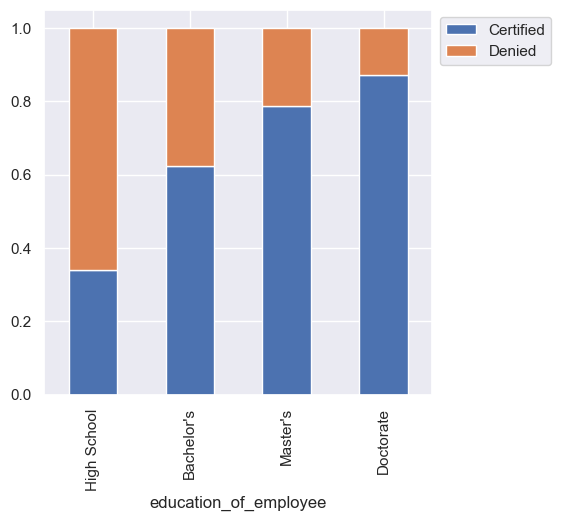

```python
stacked_barplot(df_eda, "education_of_employee", "case_status")
```

- Yes, education plays a significant role in Visa certification. We can see that those with higher education are more likely to get certified. While those with less education are less likely to get certified.
- While it’s clear that higher education correlates with higher visa certification rates, it could be useful to explore if this trend is consistent across different continents or regions of employment. This could reveal if the impact of education on visa certification is influenced by geographic factors.

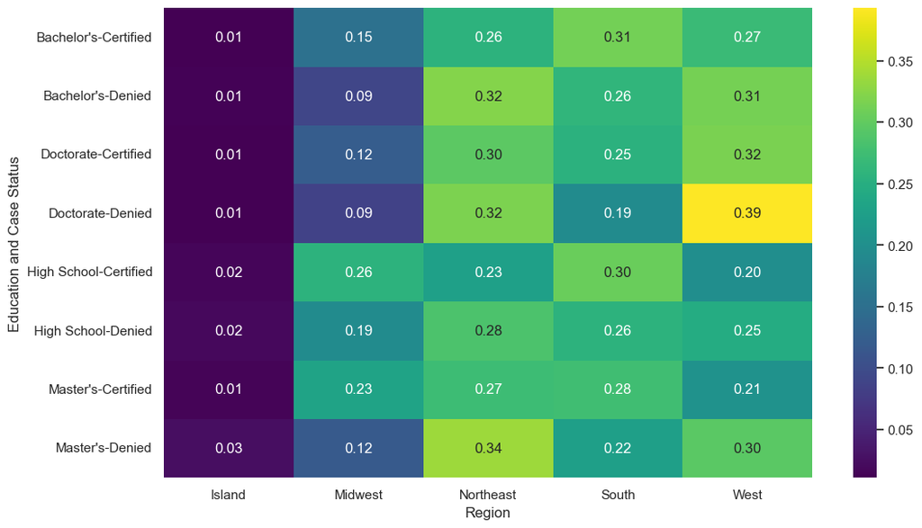

```python
plt.figure(figsize=(12, 7))
sns.heatmap(
    pd.crosstab(
        [df_eda["education_of_employee"], df["case_status"]],
        df_eda["region_of_employment"],
        normalize="index",
    ),
    annot=True,
    fmt=".2f",
    cmap="viridis",
)

plt.ylabel("Education and Case Status")
plt.xlabel("Region")
plt.show()
```

**Observations:**

- In the Island region, the distribution of education levels across Certified and Denied cases is relatively even and low, with percentages around 1-3%. This suggests that education level might not be as significant a factor in determining visa certification in this region compared to others.
- The Midwest shows a higher percentage of High School and Master's degrees among certified cases. This could imply that the region has a higher acceptance rate for individuals with these education levels, possibly reflecting the regional demand for such qualifications.
- The Northeast region appears to have a higher denial rate, particularly for those with Master’s and Doctorate degrees. This could be due to more stringent visa requirements or higher competition in this region. It’s interesting that even higher education levels don’t necessarily guarantee certification in this area.
- The South shows a significant portion of certifications among High School and Bachelor's degrees. This might indicate a regional preference or demand for these education levels, perhaps due to the types of industries prevalent in this region.
- The West region shows a notable portion of denials among Doctorates. This could be due to several factors, including perhaps an oversupply of highly educated candidates or more rigorous visa scrutiny in this region. It could also reflect the competitive job market in this area, where even highly educated candidates face challenges in securing visas.

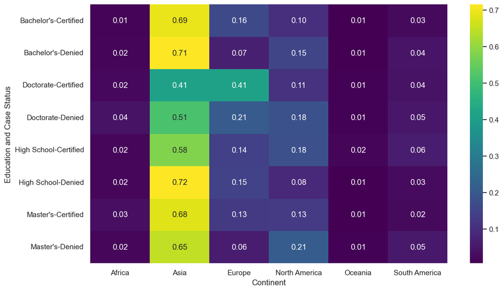

```python
plt.figure(figsize=(12, 7))
sns.heatmap(
    pd.crosstab(
        [df_eda["education_of_employee"], df["case_status"]],
        df_eda["continent"],
        normalize="index",
    ),
    annot=True,
    fmt=".2f",
    cmap="viridis",
)

plt.ylabel("Education and Case Status")
plt.xlabel("Continent")
plt.show()
```

**Observations:**

#### 2. How does the visa status vary across different continents?

The `stacked_barplot` will allow us to see the distribution of certified and denied cases among applicants from different continents and regions of employment. This will help us determine if both continent and region of employment play significant roles in visa outcomes.

```
case_status    Certified  Denied    All
continent
All                17018    8462  25480
Asia               11012    5849  16861
North America       2037    1255   3292
Europe              2957     775   3732
South America        493     359    852
Africa               397     154    551
Oceania              122      70    192
------------------------------------------------------------------------------------------------------------------------
```

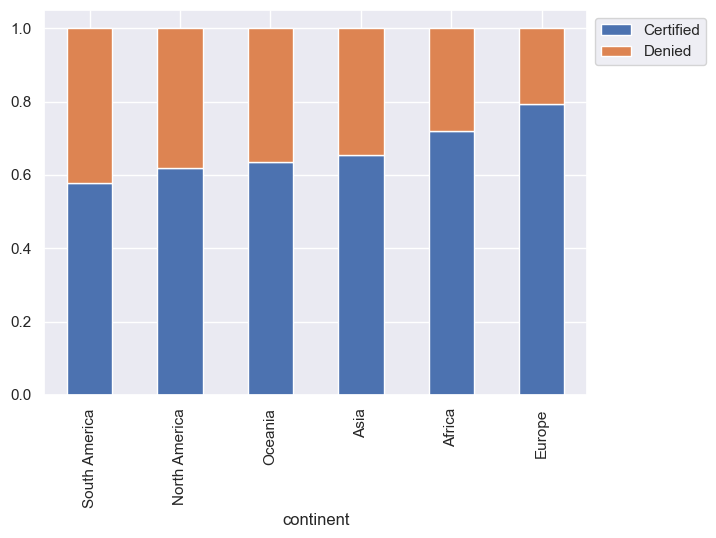

```python
stacked_barplot(df_eda, "continent", "case_status")
```

**Observations:**

- South American applicants have the highest denial rate compared to other continents. This suggests that visa applications from South America face more challenges in getting certified.
- North America and Oceania regions also show relatively high denial rates, although slightly lower than South America. This could indicate stricter visa regulations or higher competition within these regions.
- Asia shows a slightly lower denial rate compared to South America, North America, and Oceania, but it’s still significant. Given the high volume of applications from Asia, this might reflect the intense competition among applicants from this continent.
- Africa has a moderate denial rate. It’s neither as high as South America nor as low as Europe, which suggests that the continent’s visa applications are relatively balanced in terms of certification versus denial.
- European applicants have the lowest denial rate among the continents, suggesting that they have a higher success rate in getting their visas certified. This could be due to various factors, including potentially more favorable visa agreements or higher qualifications among applicants.

```
case_status           Certified  Denied    All
region_of_employment
All                       17018    8462  25480
Northeast                  4526    2669   7195
West                       4100    2486   6586
South                      4913    2104   7017
Midwest                    3253    1054   4307
Island                      226     149    375
------------------------------------------------------------------------------------------------------------------------
```

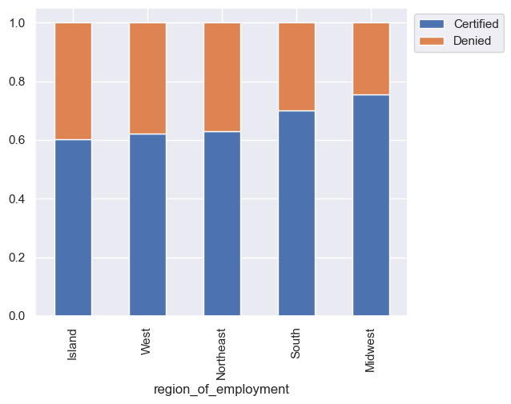

```python
stacked_barplot(df_eda, "region_of_employment", "case_status")
```

**Observations:**

- The data suggests that regions like the South and Midwest might have higher demand for foreign workers or more lenient visa policies, leading to higher certification rates. Conversely, regions like the Northeast and West, with higher denial rates, might have stricter visa policies or higher competition.

#### 3. Experienced professionals might look abroad for opportunities to improve their lifestyles and career development. Does work experience influence visa status?

The `stacked_barplot` will allow us to see the distribution of certified and denied cases among applicants with and without job experience. This will help us determine if having job experience increases the likelihood of visa certification.

```
case_status         Certified  Denied    All
has_job_experience
All                     17018    8462  25480
N                        5994    4684  10678
Y                       11024    3778  14802
------------------------------------------------------------------------------------------------------------------------
```

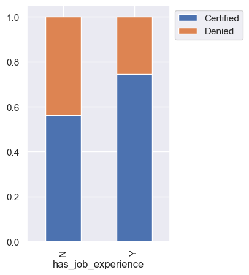

```python
stacked_barplot(df_eda, "has_job_experience", "case_status")
```

**Observations:**

- The data clearly indicates that having job experience significantly increases the likelihood of visa certification. The certification rate is much higher for applicants with job experience compared to those without.
- Employers and visa authorities may prefer candidates with proven experience in their field, which could make them more likely to contribute effectively in their roles.

#### 4. In the United States, employees are paid at different intervals. Which pay unit is most likely to be certified for a visa?

Using the `stacked_barplot` function to analyze the relationship between `unit_of_wage` and `case_status`. This approach will directly answer the question by showing which pay units (Hourly, Weekly, Monthly, Yearly) are most likely to result in a visa being certified.

```
case_status   Certified  Denied    All
unit_of_wage
All               17018    8462  25480
Year              16047    6915  22962
Hour                747    1410   2157
Week                169     103    272
Month                55      34     89
------------------------------------------------------------------------------------------------------------------------
```

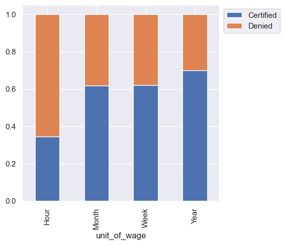

```python
stacked_barplot(df_eda, "unit_of_wage", "case_status")
```

**Observations:**

- The data suggests that jobs with yearly salaries are more likely to result in visa certification. This could be because yearly salaries are typically associated with full-time, permanent positions, which might be viewed more favorably by visa authorities.
- The high denial rate for hourly pay units might reflect concerns about job stability or the temporary nature of such positions. This insight could be important for applicants and employers aiming to increase the chances of visa approval.

#### 5. The US government has established a prevailing wage to protect local talent and foreign workers. How does the visa status change with the prevailing wage?

Using `distribution_plot_wrt_target` will allow us to to compare the distribution of `prevailing_wage` for both certified and denied cases, visually summarize the central tendency and spread of `prevailing_wage` for each case_status, and help us understand the typical range of prevailing wages without the influence of extreme values.

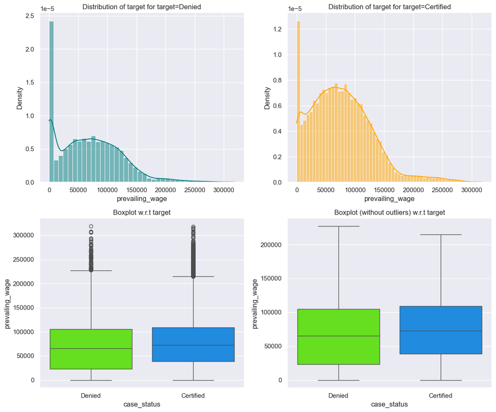

```python
distribution_plot_wrt_target(df_eda, "prevailing_wage", "case_status")
```

**Observations:**

- The prevailing wage is indeed a significant factor in visa certification, with higher wages generally increasing the likelihood of approval. This insight is crucial for both employers and applicants when considering the wage offerings in relation to visa applications.

## Data Preprocessing

We will start by performing some basic data preprocessing steps to prepare the data for the model. These steps include:

- Missing value treatments (Not Needed on our dataset).
- Feature engineering (Not Needed on our dataset).
- Outlier detection and treatment.
- Preparing data for modeling.
- Any other preprocessing steps.

```python
# Copying data to another variable to avoid any changes to original data
df_preprocessing = df_eda.copy()
```

### Missing value treatment

According to our previous analysis, there are no missing values in the dataset. Therefore no action is required.

```python
# Checking missing values across each column
missing_values = df_preprocessing.isnull().sum()
print("The number of missing values on each column of the data set is:")
missing_values

df.isnull().sum()
```

```
The number of missing values on each column of the data set is:
```

```
continent                0
education_of_employee    0
has_job_experience       0
requires_job_training    0
no_of_employees          0
yr_of_estab              0
region_of_employment     0
prevailing_wage          0
unit_of_wage             0
full_time_position       0
case_status              0
dtype: int64
```

### Outlier Detection and treatment

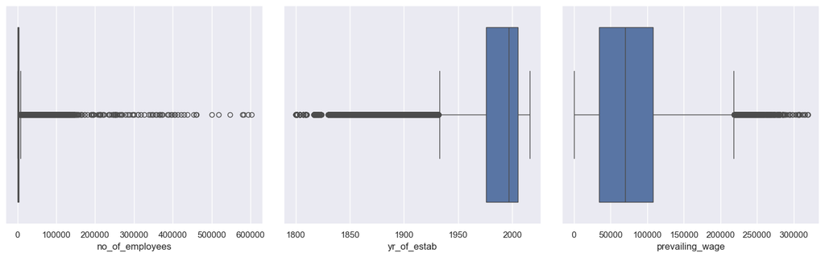

```
Summary of the numerical features, including outliers:
```

|  | no_of_employees | yr_of_estab | prevailing_wage |
| --- | --- | --- | --- |
| count | 25480.000 | 25480.000 | 25480.000 |
| mean | 5667.089 | 1979.410 | 74455.815 |
| std | 22877.917 | 42.367 | 52815.942 |
| min | 11.000 | 1800.000 | 2.137 |
| 25% | 1022.000 | 1976.000 | 34015.480 |
| 50% | 2109.000 | 1997.000 | 70308.210 |
| 75% | 3504.000 | 2005.000 | 107735.513 |
| max | 602069.000 | 2016.000 | 319210.270 |

```python
# Outlier detection using boxplot
# Creating a list of numerical columns
numeric_columns = df_preprocessing.select_dtypes(include=np.number).columns.tolist()

# Calculate the number of rows needed for the subplots
num_plots = len(num_cols)
num_rows = (num_plots // 3) + (num_plots % 3 > 0)

# Create subplots
plt.figure(figsize=(15, num_rows * 5))
for i, variable in enumerate(num_cols):
    plt.subplot(num_rows, 3, i + 1)
    sns.boxplot(data=df_preprocessing, x=variable)
    plt.tight_layout(pad=2)
plt.show()

# Check for outliers in continuous variables
outliers = df_preprocessing[num_cols].describe()
print("\nSummary of the numerical features, including outliers:")
display(outliers)
```

**Observations:**

### Feature engineering

- **There is no further feature engineering required. Therefore no action is required.**

Potential Features:

- `Company_Age`: Derived from `yr_of_estab`, this could be a proxy for company stability.
- `Employee_Size_Category`: You could bucket no_of_employees into categories (e.g., small, medium, large) to simplify the model’s understanding of company size.

### Data Preparation for Modeling

- **Our goal is to use machine learning to predict visa approvals, which involves handling a classification problem.**
- Before we proceed to build a model, we'll have to encode categorical features.
- We'll split the data into train and test to be able to evaluate the model that we build on the train data.
- When classification problems exhibit a significant imbalance in the distribution of the target classes, it is good to use stratified sampling to ensure that relative class frequencies are approximately preserved in train and test sets.
- This is done using the `stratify` parameter in the train_test_split function.

```python
# Copying data to another variable to avoid any changes to original data
df_modeling = df_preprocessing.copy()
```

```python
# Encoding the target variable
df_modeling["case_status"] = df_modeling["case_status"].apply(
    lambda x: 1 if x == "Certified" else 0
)

# One-hot encoding Encoding the categorical variables
X = df_modeling.drop(["case_status"], axis=1)
y = df_modeling["case_status"]

X = pd.get_dummies(X, drop_first=True)
```

```python
# Splitting the data into training and test sets
X_train, X_test, y_train, y_test = train_test_split(X, y, random_state=1, stratify=y)
print(
    "There are",
    X_train.shape[0],
    "rows and",
    X_train.shape[1],
    "columns in the Training set.",
    X_train.shape,
)
print(
    "There are",
    X_test.shape[0],
    "rows and",
    X_test.shape[1],
    "columns in the Test set.",
    X_test.shape,
)
```

```
There are 19110 rows and 21 columns in the Training set. (19110, 21)
There are 6370 rows and 21 columns in the Test set. (6370, 21)
```

```python
print("Percentage of classes in training set:")
print(y_train.value_counts(normalize=True))
```

```
Percentage of classes in training set:
case_status
1   0.668
0   0.332
Name: proportion, dtype: float64
```

```python
print("Percentage of classes in test set:")
print(y_test.value_counts(normalize=True))
```

```
Percentage of classes in test set:
case_status
1   0.668
0   0.332
Name: proportion, dtype: float64
```

- The class distribution in both the training and test sets is identical to the original dataset (approximately 66.8% Certified and 33.2% Denied). This confirms that the stratified sampling worked as intended, ensuring that the class imbalance is consistently represented in both sets.
- Now that we have prepared the data for modeling, we can move on to building the models.

## Model Building

### Model Criterion - F1 Score

#### Model can make wrong predictions as the following:

1. The model predicts that the visa application will get certified, but in reality, the visa application should be denied. **False Positive.**
2. The model predicts that the visa application will not get certified, but in reality, the visa application should be certified. **False Negative.**

#### Which case is more important?

- Both cases are important in terms of reducing the losses because:
  - If a visa is certified when it should have been denied, an unqualified employee may fill the position, while U.S. citizens miss the opportunity to work in that role.
  - If a visa is denied when it should have been certified, the U.S. will lose a valuable human resource that could contribute to the economy.

#### How to reduce the losses?

- The `F1 Score` can be used as the metric for model evaluation. A higher F1 score increases the likelihood of minimizing both False Negatives and False Positives.
- We will use balanced class weights so that the model focuses equally on both classes.

**First, let's create functions to calculate different metrics and confusion matrix so that we don't have to use the same code repeatedly for each model.**

- The `model_performance_classification_sklearn` function will be used to check the model performance of models.
- The `confusion_matrix_sklearn` function will be used to plot the confusion matrix.

```python
# defining a function to compute different metrics to check performance of a classification model built using sklearn
def model_performance_classification_sklearn(model, predictors, target):
    """
    Function to compute different metrics to check classification model performance

    model: classifier
    predictors: independent variables
    target: dependent variable
    """

    # predicting using the independent variables
    pred = model.predict(predictors)

    acc = accuracy_score(target, pred)  # to compute Accuracy
    recall = recall_score(target, pred)  # to compute Recall
    precision = precision_score(target, pred)  # to compute Precision
    f1 = f1_score(target, pred)  # to compute F1-score

    # creating a dataframe of metrics
    df_perf = pd.DataFrame(
        {
            "Accuracy": acc,
            "Recall": recall,
            "Precision": precision,
            "F1": f1,
        },
        index=[0],
    )

    return df_perf
```

```python
def confusion_matrix_sklearn(model, predictors, target):
    """
    To plot the confusion_matrix with percentages

    model: classifier
    predictors: independent variables
    target: dependent variable
    """
    y_pred = model.predict(predictors)
    cm = confusion_matrix(target, y_pred)
    labels = np.asarray(
        [
            ["{0:0.0f}".format(item) + "\n{0:.2%}".format(item / cm.flatten().sum())]
            for item in cm.flatten()
        ]
    ).reshape(2, 2)

    plt.figure(figsize=(6, 4))
    sns.heatmap(cm, annot=labels, fmt="")
    plt.ylabel("True label")
    plt.xlabel("Predicted label")
```

### Decision Tree - Model Building and Hyperparameter Tuning

- **Gini Impurity** is a metric used to evaluate the “purity” of a node in a decision tree. It quantifies the likelihood of an incorrect classification of a randomly chosen element from a dataset, based on the distribution of classes in that node.
- In the context of our problem, where we want to predict whether a visa application will be certified or denied, we need to create decision rules that best separate the two classes (Certified vs. Denied) at each node in the tree.
- Since we want to make the most accurate predictions about whether a visa application will be certified or denied. By choosing splits that minimize Gini Impurity, the decision tree is making the "cleanest" separations between Certified and Denied applications.
- A split with low Gini Impurity would mean that for most cases within that node, the model can confidently predict the outcome. For example, if a node after a split predominantly contains Certified applications, the model has learned a strong pattern.

#### Decision Tree Model

```python
from sklearn.tree import DecisionTreeClassifier

# Initialize the decision tree classifier with Gini impurity
dtc_estimator = DecisionTreeClassifier(
    criterion="gini", class_weight="balanced", random_state=1
)

# Train the model on the training data
dtc_estimator.fit(X_train, y_train)
```

```
DecisionTreeClassifier(class_weight='balanced', random_state=1)
```

##### Evaluate Decision Tree model on the training data

```
Training Performance:
```

|  | Accuracy | Recall | Precision | F1 |
| --- | --- | --- | --- | --- |
| 0 | 1.000 | 1.000 | 1.000 | 1.000 |

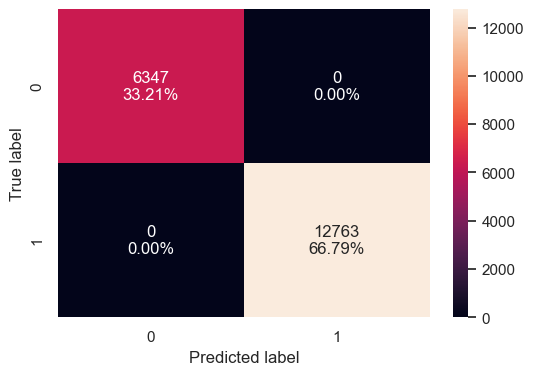

```python
# Evaluate the model on the training data
print("Training Performance:")
dt_train_perf = model_performance_classification_sklearn(
    dtc_estimator, X_train, y_train
)
display(dt_train_perf)

# Plot the confusion matrix for the training set
confusion_matrix_sklearn(dtc_estimator, X_train, y_train)
```

##### Evaluate Decision Tree model on the test data

```
Test Performance:
```

|  | Accuracy | Recall | Precision | F1 |
| --- | --- | --- | --- | --- |
| 0 | 0.645 | 0.732 | 0.735 | 0.734 |

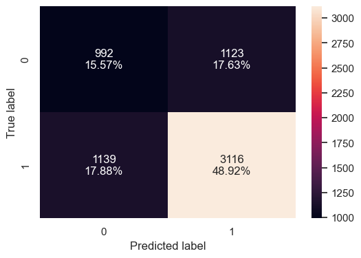

```python
# Evaluate the model on the test data
print("\nTest Performance:")
dt_test_perf = model_performance_classification_sklearn(dtc_estimator, X_test, y_test)
display(dt_test_perf)

# Plot the confusion matrix for the test set
confusion_matrix_sklearn(dtc_estimator, X_test, y_test)
```

**Observations:**

- The decision tree is overfitting on the training data, which results in a drop in performance on the test data.
- We will have to find a way to optimize the decision tree model and the best way is to do hyperparameter tuning.

#### Decision Tree - Hyperparameter Tuning

> **Note**
> 1. Sample parameter grids have been provided to do necessary hyperparameter tuning. These sample grids are expected to provide a balance between model performance improvement and execution time. One can extend/reduce the parameter grid based on execution time and system configuration.
> - Please note that if the parameter grid is extended to improve the model performance further, the execution time will increase
> - For Decision Trees:

```
param_grid = {
    'max_depth': np.arange(2,6),
    'min_samples_leaf': [1, 4, 7],
    'max_leaf_nodes' : [10, 15],
    'min_impurity_decrease': [0.0001,0.001]
}
```

```python
# Choose the type of classifier.
dtc_tuned = DecisionTreeClassifier(class_weight="balanced", random_state=1)

# Grid of parameters to choose from
parameters = {
    "max_depth": np.arange(2, 6),
    "min_samples_leaf": [1, 4, 7],
    "max_leaf_nodes": [10, 15],
    "min_impurity_decrease": [0.0001, 0.001],
}

# Type of scoring used to compare parameter combinations
scorer = metrics.make_scorer(metrics.f1_score)

# Run the grid search with n_jobs = -1 to use all available processors
grid_obj = GridSearchCV(dtc_tuned, parameters, scoring=scorer, cv=5, n_jobs=-1)

# Fit the grid_obj on the training data
grid_obj = grid_obj.fit(X_train, y_train)

# Set the dtc_tuned to the best combination of parameters
dtc_tuned = grid_obj.best_estimator_

# Fit the best algorithm to the data.
dtc_tuned.fit(X_train, y_train)
```

```
DecisionTreeClassifier(class_weight='balanced', max_depth=5, max_leaf_nodes=15,
                       min_impurity_decrease=0.0001, random_state=1)
```

##### Evaluate Decision Tree Hyperparameter Tuning model on the training data

```
Training Performance:
```

|  | Accuracy | Recall | Precision | F1 |
| --- | --- | --- | --- | --- |
| 0 | 0.710 | 0.724 | 0.821 | 0.769 |

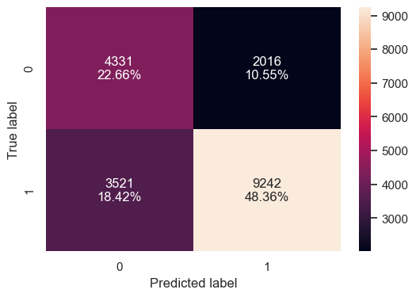

```python
# Evaluate the model on the training data
print("Training Performance:")
dtt_train_perf = model_performance_classification_sklearn(dtc_tuned, X_train, y_train)
display(dtt_train_perf)

# Plot the confusion matrix for the training set
confusion_matrix_sklearn(dtc_tuned, X_train, y_train)
```

##### Evaluate Decision Tree Hyperparameter Tuning model on the test data

```
Test Performance:
```

|  | Accuracy | Recall | Precision | F1 |
| --- | --- | --- | --- | --- |
| 0 | 0.707 | 0.732 | 0.811 | 0.769 |

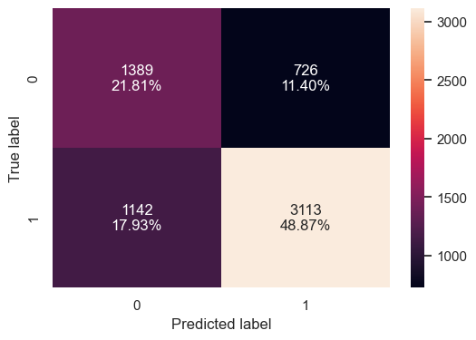

```python
# Evaluate the model on the test data
print("Test Performance:")
dtt_test_perf = model_performance_classification_sklearn(dtc_tuned, X_test, y_test)
display(dtt_test_perf)

# Plot the confusion matrix for the test set
confusion_matrix_sklearn(dtc_tuned, X_test, y_test)
```

**Observations:**

- We can se that the model is overall better with hyperparameter tuning.
- We can also see that the performance is comparable between the training and test data.
- Overall, Decision Tree with Hyperparameter Tuning is a good model and preferred to Decision Tree without Hyperparameter Tuning.

### Bagging - Model Building and Hyperparameter Tuning

#### Bagging Classifier Model

```python
# base_estimator for bagging classifier is a decision tree by default
bc_estimator = BaggingClassifier(random_state=1)
bc_estimator.fit(X_train, y_train)
```

```
BaggingClassifier(random_state=1)
```

##### Evaluate Bagging Classifier Model on the training data

```
Training Performance:
```

|  | Accuracy | Recall | Precision | F1 |
| --- | --- | --- | --- | --- |
| 0 | 0.985 | 0.984 | 0.993 | 0.989 |

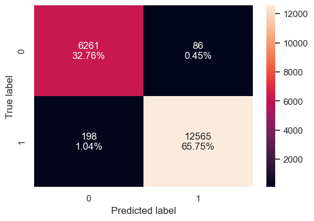

```python
# Evaluate the model on the training data
print("Training Performance:")
bc_train_perf = model_performance_classification_sklearn(bc_estimator, X_train, y_train)
display(bc_train_perf)

# Plot the confusion matrix for the training set
confusion_matrix_sklearn(bc_estimator, X_train, y_train)
```

##### Evaluate Bagging Classifier Model on the test data

```
Test Performance:
```

|  | Accuracy | Recall | Precision | F1 |
| --- | --- | --- | --- | --- |
| 0 | 0.697 | 0.775 | 0.772 | 0.773 |

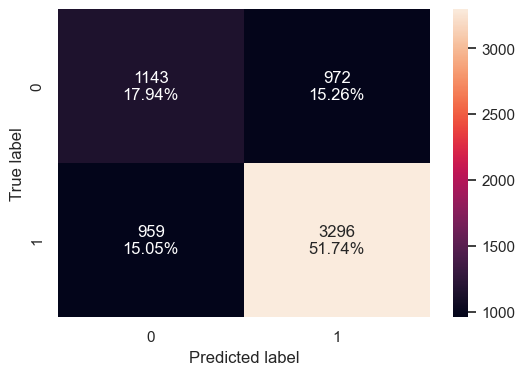

```python
# Evaluate the model on the test data
print("Test Performance:")
bc_test_perf = model_performance_classification_sklearn(bc_estimator, X_test, y_test)
display(bc_test_perf)

# Plot the confusion matrix for the test set
confusion_matrix_sklearn(bc_estimator, X_test, y_test)
```

- The Bagging Classifier is performing better on the test set compared to the Decision Tree, particularly in terms of the F1 score, which is crucial for balancing false positives and false negatives. The higher F1 score suggests that the Bagging Classifier is making fewer errors in predicting visa certification outcomes.
- While the training accuracy is still high, the test performance indicates that the Bagging Classifier is less prone to overfitting than the single Decision Tree, thanks to the ensemble approach of bagging.
- While the performance between the training and test sets are not as comparable. The Bagging Classifier is performing better on the test set compared to the Decision Tree, particularly in terms of the F1 score, which is crucial for balancing false positives and false negatives.

#### Bagging Classifier- Hyper Parameter Tunning

> **Note**
> 1. Sample parameter grids have been provided to do necessary hyperparameter tuning. These sample grids are expected to provide a balance between model performance improvement and execution time. One can extend/reduce the parameter grid based on execution time and system configuration.
> - Please note that if the parameter grid is extended to improve the model performance further, the execution time will increase
> - For Bagging Classifier:

```
param_grid = {
    'max_samples': [0.8,0.9,1],
    'max_features': [0.7,0.8,0.9],
    'n_estimators' : [30,50,70],
}
```

```python
# Choose the type of classifier.
bc_tuned = BaggingClassifier(random_state=1)

# Grid of parameters to choose from
## add from article
parameters = {
    "max_samples": [0.8, 0.9, 1],
    "max_features": [0.7, 0.8, 0.9],
    "n_estimators": [30, 50, 70],
}

# Type of scoring used to compare parameter combinations
acc_scorer = metrics.make_scorer(metrics.f1_score)

# Run the grid search
grid_obj = GridSearchCV(bc_tuned, parameters, scoring=acc_scorer, cv=5)
grid_obj = grid_obj.fit(X_train, y_train)

# Set the clf to the best combination of parameters
bc_tuned = grid_obj.best_estimator_

# Fit the best algorithm to the data.
bc_tuned.fit(X_train, y_train)
```

```
BaggingClassifier(max_features=0.7, max_samples=0.9, n_estimators=70,
                  random_state=1)
```

##### Evaluate Bagging Classifier Hyper Parameter Tunning model on the training data

```
Training Performance:
```

|  | Accuracy | Recall | Precision | F1 |
| --- | --- | --- | --- | --- |
| 0 | 1.000 | 1.000 | 1.000 | 1.000 |

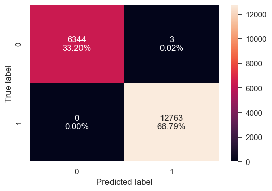

```python
# Evaluate the model on the training data
print("Training Performance:")
bct_train_perf = model_performance_classification_sklearn(bc_tuned, X_train, y_train)
display(bct_train_perf)

# Plot the confusion matrix for the training set
confusion_matrix_sklearn(bc_tuned, X_train, y_train)
```

##### Evaluate Bagging Classifier Hyper Parameter Tunning model on the test data

```
Test Performance:
```

|  | Accuracy | Recall | Precision | F1 |
| --- | --- | --- | --- | --- |
| 0 | 0.718 | 0.887 | 0.741 | 0.808 |

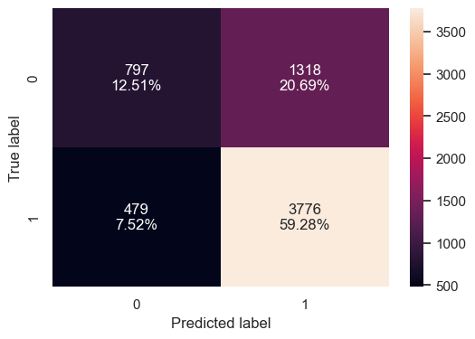

```python
# Evaluate the model on the test data
print("Test Performance:")
bct_test_perf = model_performance_classification_sklearn(bc_tuned, X_test, y_test)
display(bct_test_perf)

# Plot the confusion matrix for the test set
confusion_matrix_sklearn(bc_tuned, X_test, y_test)
```

- The model correctly predicted all cases in the training set, indicating it fits the training data perfectly. However, this suggests that the model is still overfitting on the training data.
- The model is making some mistakes, particularly with false positives (predicting certification when it should be denied) and false negatives (predicting denial when it should be certified), but the performance is now more realistic and better balanced.
- The F1 score on the test set has improved significantly to 0.808, indicating a better balance between precision and recall. The overfitting seen in the training performance is still present, but the test performance is much more realistic and useful.
- While the performance on the training and test set are still not as comparable, among the test models that have been built, the Bagging Classifier with hyperparameter tuning is the best performing model.

### Random Forest - Model Building and Hyperparameter Tuning

#### Random Forest Model

```python
# Train the random forest classifier
rfc_estimator = RandomForestClassifier(random_state=1)
rfc_estimator.fit(X_train, y_train)
```

```
RandomForestClassifier(random_state=1)
```

##### Evaluate Random Forest Model on the Training data

```
Training Performance:
```

|  | Accuracy | Recall | Precision | F1 |
| --- | --- | --- | --- | --- |
| 0 | 1.000 | 1.000 | 1.000 | 1.000 |

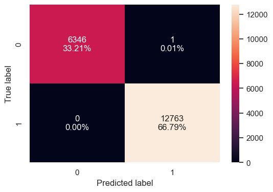

```python
# Evaluate the model on the training data
print("Training Performance:")
rf_train_perf = model_performance_classification_sklearn(
    rfc_estimator, X_train, y_train
)
display(rf_train_perf)

# Plot the confusion matrix for the training set
confusion_matrix_sklearn(rfc_estimator, X_train, y_train)
```

##### Evaluate Random Forest Model on the Test data

```
Test Performance:
```

|  | Accuracy | Recall | Precision | F1 |
| --- | --- | --- | --- | --- |
| 0 | 0.722 | 0.840 | 0.766 | 0.801 |

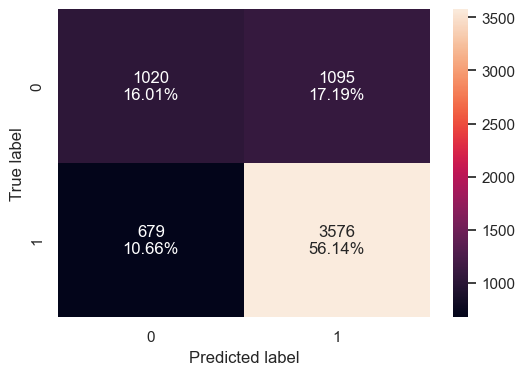

```python
# Evaluate the model on the test data
print("Test Performance:")
rf_test_perf = model_performance_classification_sklearn(rfc_estimator, X_test, y_test)
display(rf_test_perf)

# Plot the confusion matrix for the test set
confusion_matrix_sklearn(rfc_estimator, X_test, y_test)
```

- The model has perfectly predicted all cases in the training set, which strongly suggests overfitting. The Random Forest has learned the training data very well, but this doesn't necessarily mean it will perform well on unseen data.
- The model still makes some mistakes, particularly with false positives (predicting certification when it should be denied) and false negatives (predicting denial when it should be certified), but the performance is fairly strong.
- The Random Forest shows perfect performance on the training data, which indicates overfitting. This is common with complex models like Random Forests that can learn very intricate patterns in the training data.
- Despite the overfitting, the model generalizes reasonably well to the test set, achieving a decent F1 score. The test performance is slightly better than the decision tree model, showing the strength of ensemble methods.

#### Random Forest Hyperparameter Tuning Model

> **Note**
> 1. Sample parameter grids have been provided to do necessary hyperparameter tuning. These sample grids are expected to provide a balance between model performance improvement and execution time. One can extend/reduce the parameter grid based on execution time and system configuration.
> - Please note that if the parameter grid is extended to improve the model performance further, the execution time will increase
> - For Random Forest:

```
param_grid = {
    "n_estimators": [50,110,25],
    "min_samples_leaf": np.arange(1, 4),
    "max_features": [np.arange(0.3, 0.6, 0.1),'sqrt'],
    "max_samples": np.arange(0.4, 0.7, 0.1)
}
```

```python
# from sklearn.ensemble import RandomForestClassifier
# from sklearn.model_selection import GridSearchCV
# from sklearn import metrics

# Choose the type of classifier.
rfc_tuned = RandomForestClassifier(random_state=1, oob_score=True, bootstrap=True)

parameters = {
    "n_estimators": [50, 110, 25],
    "min_samples_leaf": np.arange(1, 4),
    "max_features": [np.arange(0.3, 0.6, 0.1), "sqrt"],
    "max_samples": np.arange(0.4, 0.7, 0.1),
}

# Type of scoring used to compare parameter combinations
acc_scorer = metrics.make_scorer(metrics.f1_score)

# Run the grid search with cv = 5 and n_jobs = -1
grid_obj = GridSearchCV(rfc_tuned, parameters, scoring=acc_scorer, cv=5, n_jobs=-1)

# Fit the grid_obj on the training data
grid_obj = grid_obj.fit(X_train, y_train)

# Set the clf to the best combination of parameters
rfc_tuned = grid_obj.best_estimator_

# Fit the best algorithm to the data.
rfc_tuned.fit(X_train, y_train)
```

```
RandomForestClassifier(max_samples=0.4, min_samples_leaf=3, n_estimators=110,
                       oob_score=True, random_state=1)
```

##### Evaluate Random Forest Hyperparameter Tuning Model on the Training data

```
Training Performance:
```

|  | Accuracy | Recall | Precision | F1 |
| --- | --- | --- | --- | --- |
| 0 | 0.795 | 0.905 | 0.811 | 0.855 |

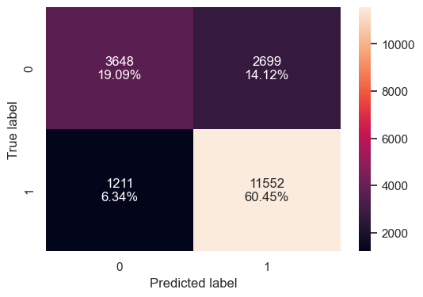

```python
# Evaluate the model on the training data
print("Training Performance:")
rft_train_perf = model_performance_classification_sklearn(rfc_tuned, X_train, y_train)
display(rft_train_perf)

# Plot the confusion matrix for the training set
confusion_matrix_sklearn(rfc_tuned, X_train, y_train)
```

##### Evaluate Random Forest Hyperparameter Tuning Model on the Test data

```
Test Performance:
```

|  | Accuracy | Recall | Precision | F1 |
| --- | --- | --- | --- | --- |
| 0 | 0.738 | 0.868 | 0.770 | 0.816 |

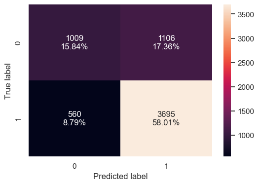

```python
# Evaluate the model on the test data
print("Test Performance:")
rft_test_perf = model_performance_classification_sklearn(rfc_tuned, X_test, y_test)
display(rft_test_perf)

# Plot the confusion matrix for the test set
confusion_matrix_sklearn(rfc_tuned, X_test, y_test)
```

### Model Performance Comparison Decision Tree, Bagging Classifier, and Random Forest Models

```python
# Defining list of models
models = [
    dtc_estimator,
    dtc_tuned,
    bc_estimator,
    bc_tuned,
    rfc_estimator,
    rfc_tuned,
]

# Defining empty lists to add train and test results
train_acc = []
test_acc = []
recall_train = []
recall_test = []
precision_train = []
precision_test = []
f1_train = []
f1_test = []

# Looping through all the models to get the accuracy, recall, precision, and F1 scores
for model in models:
    # Get metrics for training data
    train_perf = model_performance_classification_sklearn(model, X_train, y_train)
    # Get metrics for test data
    test_perf = model_performance_classification_sklearn(model, X_test, y_test)

    # Append the metrics to respective lists with adjusted rounding
    train_acc.append(np.round(train_perf["Accuracy"][0], 4))
    test_acc.append(np.round(test_perf["Accuracy"][0], 4))
    recall_train.append(np.round(train_perf["Recall"][0], 4))
    recall_test.append(np.round(test_perf["Recall"][0], 4))
    precision_train.append(np.round(train_perf["Precision"][0], 4))
    precision_test.append(np.round(test_perf["Precision"][0], 4))
    f1_train.append(np.round(train_perf["F1"][0], 4))
    f1_test.append(np.round(test_perf["F1"][0], 4))
```

```python
# Creating a DataFrame to compare model performance
comparison_frame = pd.DataFrame(
    {
        "Model": [
            "Decision Tree Model",
            "Tuned Decision Tree Model",
            "Bagging Classifier Model",
            "Tuned Bagging Classifier Model",
            "Random Forest Model",
            "Tuned Random Forest Model",
        ],
        "Train_Accuracy": train_acc,
        "Test_Accuracy": test_acc,
        "Train_Recall": recall_train,
        "Test_Recall": recall_test,
        "Train_Precision": precision_train,
        "Test_Precision": precision_test,
        "Train_F1_Score": f1_train,
        "Test_F1_Score": f1_test,
    }
)

# Displaying the comparison DataFrame
display(comparison_frame)
```

|  | Model | Train_Accuracy | Test_Accuracy | Train_Recall | Test_Recall | Train_Precision | Test_Precision | Train_F1_Score | Test_F1_Score |
| --- | --- | --- | --- | --- | --- | --- | --- | --- | --- |
| 0 | Decision Tree Model | 1.000 | 0.645 | 1.000 | 0.732 | 1.000 | 0.735 | 1.000 | 0.734 |
| 1 | Tuned Decision Tree Model | 0.710 | 0.707 | 0.724 | 0.732 | 0.821 | 0.811 | 0.769 | 0.769 |
| 2 | Bagging Classifier Model | 0.985 | 0.697 | 0.985 | 0.775 | 0.993 | 0.772 | 0.989 | 0.773 |
| 3 | Tuned Bagging Classifier Model | 1.000 | 0.718 | 1.000 | 0.887 | 1.000 | 0.741 | 1.000 | 0.808 |
| 4 | Random Forest Model | 1.000 | 0.722 | 1.000 | 0.840 | 1.000 | 0.766 | 1.000 | 0.801 |
| 5 | Tuned Random Forest Model | 0.795 | 0.739 | 0.905 | 0.868 | 0.811 | 0.770 | 0.855 | 0.816 |

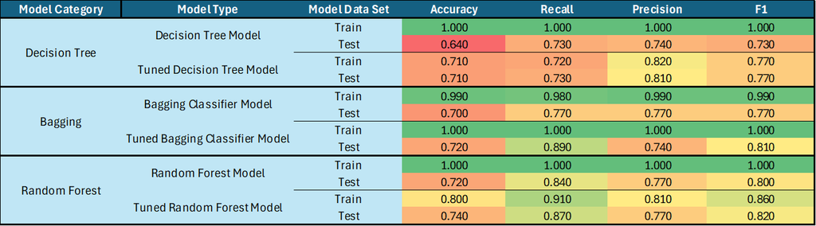

**Bagging Observations:**

### AdaBoosting - Model Building and Hyperparameter Tuning

#### AdaBoosting Model

```python
abc_estimator = AdaBoostClassifier(random_state=1)
abc_estimator.fit(X_train, y_train)
```

```
AdaBoostClassifier(random_state=1)
```

##### Evaluate AdaBoosting Model on the Training data

```
Training Performance:
```

|  | Accuracy | Recall | Precision | F1 |
| --- | --- | --- | --- | --- |
| 0 | 0.739 | 0.889 | 0.761 | 0.820 |

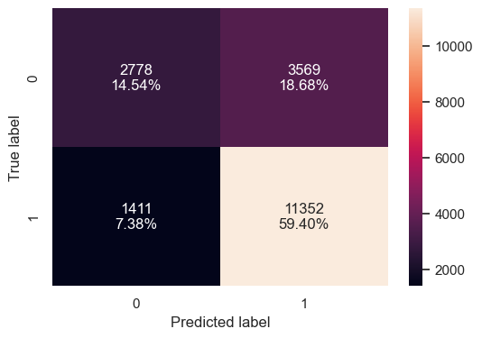

```python
# Evaluate the model on the training data
print("Training Performance:")
abc_train_perf = model_performance_classification_sklearn(
    abc_estimator, X_train, y_train
)
display(abc_train_perf)

# Plot the confusion matrix for the training set
confusion_matrix_sklearn(abc_estimator, X_train, y_train)
```

##### Evaluate AdaBoosting Model on the Test data

```
Test Performance:
```

|  | Accuracy | Recall | Precision | F1 |
| --- | --- | --- | --- | --- |
| 0 | 0.727 | 0.884 | 0.752 | 0.812 |

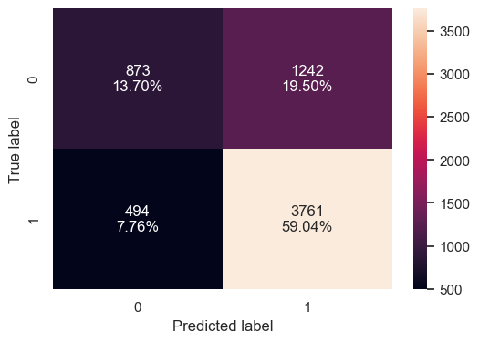

```python
# Evaluate the model on the test data
print("Test Performance:")
abc_test_perf = model_performance_classification_sklearn(abc_estimator, X_test, y_test)
display(abc_test_perf)

# Plot the confusion matrix for the test set
confusion_matrix_sklearn(abc_estimator, X_test, y_test)
```

**Observations:**

- Regular AdaBoosting model shows the training and test performance to be very comparable, which indicates that it is not overfitting.
- The performance on the training data is slightly better than on the testing data.
- Nonetheless, the performance is comparable to previous models in terms of F1 score.

#### AdaBoosting Hyperparameter Tuning Model

> **Note**
> 1. Sample parameter grids have been provided to do necessary hyperparameter tuning. These sample grids are expected to provide a balance between model performance improvement and execution time. One can extend/reduce the parameter grid based on execution time and system configuration.
> - Please note that if the parameter grid is extended to improve the model performance further, the execution time will increase
> - For Adaboost:

```
param_grid = {
    "n_estimators": np.arange(50,110,25),
    "learning_rate": [0.01,0.1,0.05],
    "base_estimator": [
        DecisionTreeClassifier(max_depth=2, random_state=1),
        DecisionTreeClassifier(max_depth=3, random_state=1),
    ],
}
```

```python
# Choose the type of classifier.
abc_tuned = AdaBoostClassifier(random_state=1)

# Grid of parameters to choose from
## add from article
parameters = {
    # Let's try different max_depth for base_estimator
    "n_estimators": np.arange(50, 110, 25),
    "learning_rate": [0.01, 0.1, 0.05],
    "estimator": [
        DecisionTreeClassifier(max_depth=2, random_state=1),
        DecisionTreeClassifier(max_depth=3, random_state=1),
    ],
}

# Type of scoring used to compare parameter combinations
acc_scorer = metrics.make_scorer(metrics.f1_score)

# Run the grid search
grid_obj = GridSearchCV(abc_tuned, parameters, scoring=acc_scorer, cv=5)
grid_obj = grid_obj.fit(X_train, y_train)

# Set the clf to the best combination of parameters
abc_tuned = grid_obj.best_estimator_

# Fit the best algorithm to the data.
abc_tuned.fit(X_train, y_train)
```

```
AdaBoostClassifier(estimator=DecisionTreeClassifier(max_depth=3,
                                                    random_state=1),
                   learning_rate=0.05, n_estimators=100, random_state=1)
```

##### Evaluate AdaBoosting Hyperparameter Tuning Model on the Training data

```
Training Performance:
```

|  | Accuracy | Recall | Precision | F1 |
| --- | --- | --- | --- | --- |
| 0 | 0.754 | 0.887 | 0.776 | 0.828 |

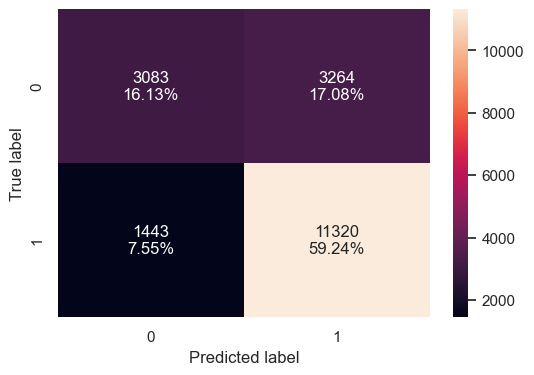

```python
# Evaluate the model on the training data
print("Training Performance:")
abct_train_perf = model_performance_classification_sklearn(abc_tuned, X_train, y_train)
display(abct_train_perf)

# Plot the confusion matrix for the training set
confusion_matrix_sklearn(abc_tuned, X_train, y_train)
```

##### Evaluate AdaBoosting Hyperparameter Tuning Model on the Test data

```
Test Performance:
```

|  | Accuracy | Recall | Precision | F1 |
| --- | --- | --- | --- | --- |
| 0 | 0.739 | 0.882 | 0.764 | 0.819 |

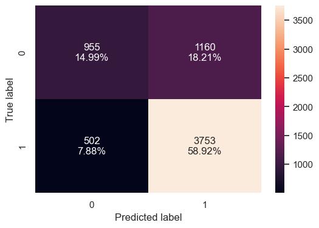

```python
# Evaluate the model on the test data
print("Test Performance:")
abct_test_perf = model_performance_classification_sklearn(abc_tuned, X_test, y_test)
display(abct_test_perf)

# Plot the confusion matrix for the test set
confusion_matrix_sklearn(abc_tuned, X_test, y_test)
```

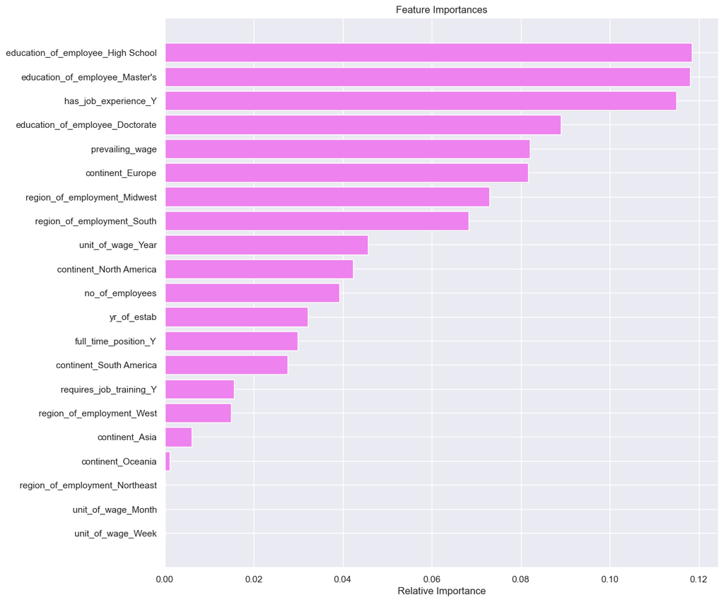

```python
importances = abc_tuned.feature_importances_
indices = np.argsort(importances)
feature_names = list(X.columns)

plt.figure(figsize=(12, 12))
plt.title("Feature Importances")
plt.barh(range(len(indices)), importances[indices], color="violet", align="center")
plt.yticks(range(len(indices)), [feature_names[i] for i in indices])
plt.xlabel("Relative Importance")
plt.show()
```

**Observations:**

- We can see that performance improved when the AdaBoosting model is tuned.
- Overall, we got a better performance in F1 that is also very comparable.
- We can also see that among the top 3 features that seemingly have the highest importance are: `education_of_employee` (If they have highschool or masters) and if they had previous `job_experience`.
- While the least important features are `unit_of_wage_Week`, `unit_of_wage_Month`, `region_of_employment_Northeast`, and wether the applicant comes from Asia, or Oceania.
- We should pay attention in future models to see if the weights match this model.

#### Gradient Boosting Classifier Model

```python
gbc_estimator = GradientBoostingClassifier(random_state=1)
gbc_estimator.fit(X_train, y_train)
```

```
GradientBoostingClassifier(random_state=1)
```

##### Evaluate Gradient Boosting Classifier Model on the Training data

```
Training Performance:
```

|  | Accuracy | Recall | Precision | F1 |
| --- | --- | --- | --- | --- |
| 0 | 0.759 | 0.881 | 0.785 | 0.830 |

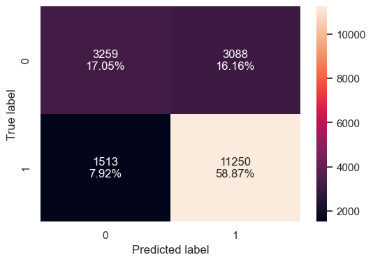

```python
# Evaluate the model on the training data
print("Training Performance:")
gbc_train_perf = model_performance_classification_sklearn(
    gbc_estimator, X_train, y_train
)
display(gbc_train_perf)

# Plot the confusion matrix for the training set
confusion_matrix_sklearn(gbc_estimator, X_train, y_train)
```

##### Evaluate Gradient Boosting Classifier Model on the Test data

```
Test Performance:
```

|  | Accuracy | Recall | Precision | F1 |
| --- | --- | --- | --- | --- |
| 0 | 0.741 | 0.873 | 0.769 | 0.818 |

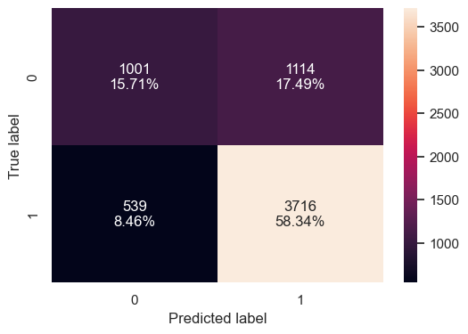

```python
# Evaluate the model on the test data
print("Test Performance:")
gbc_test_perf = model_performance_classification_sklearn(gbc_estimator, X_test, y_test)
display(gbc_test_perf)

# Plot the confusion matrix for the test set
confusion_matrix_sklearn(gbc_estimator, X_test, y_test)
```

**Observations:**

- This model performs better on the training data than the previous AdaBoosting models, but F1 score in the test data is lower. Regardless, these changes are only by a small amount.

#### Gradient Boosting Classifier Hyperparameter Tuning Model

> **Note**
> 1. Sample parameter grids have been provided to do necessary hyperparameter tuning. These sample grids are expected to provide a balance between model performance improvement and execution time. One can extend/reduce the parameter grid based on execution time and system configuration.
> - Please note that if the parameter grid is extended to improve the model performance further, the execution time will increase
> - For Gradient Boosting:

```
param_grid = {
    "init": [AdaBoostClassifier(random_state=1),DecisionTreeClassifier(random_state=1)],
    "n_estimators": np.arange(50,110,25),
    "learning_rate": [0.01,0.1,0.05],
    "subsample":[0.7,0.9],
    "max_features":[0.5,0.7,1],
}
```

```python
# Choose the type of classifier.
gbc_tuned = GradientBoostingClassifier(
    init=AdaBoostClassifier(random_state=1), random_state=1
)

# Grid of parameters to choose from
## add from article
parameters = {
    "init": [
        AdaBoostClassifier(random_state=1),
        DecisionTreeClassifier(random_state=1),
    ],
    "n_estimators": np.arange(50, 110, 25),
    "learning_rate": [0.01, 0.1, 0.05],
    "subsample": [0.7, 0.9],
    "max_features": [0.5, 0.7, 1],
}

# Type of scoring used to compare parameter combinations
acc_scorer = metrics.make_scorer(metrics.f1_score)

# Run the grid search
grid_obj = GridSearchCV(gbc_tuned, parameters, scoring=acc_scorer, cv=5)
grid_obj = grid_obj.fit(X_train, y_train)

# Set the clf to the best combination of parameters
gbc_tuned = grid_obj.best_estimator_

# Fit the best algorithm to the data.
gbc_tuned.fit(X_train, y_train)
```

```
GradientBoostingClassifier(init=AdaBoostClassifier(random_state=1),
                           learning_rate=0.05, max_features=0.7, random_state=1,
                           subsample=0.9)
```

##### Evaluate Gradient Boosting Classifier Hyperparameter Tuning Model on the Training data

```
Training Performance:
```

|  | Accuracy | Recall | Precision | F1 |
| --- | --- | --- | --- | --- |
| 0 | 0.756 | 0.885 | 0.779 | 0.829 |

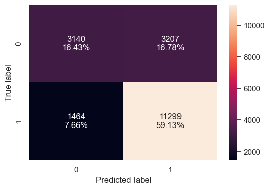

```python
# Evaluate the model on the training data
print("Training Performance:")
gbct_train_perf = model_performance_classification_sklearn(gbc_tuned, X_train, y_train)
display(gbct_train_perf)

# Plot the confusion matrix for the training set
confusion_matrix_sklearn(gbc_tuned, X_train, y_train)
```

##### Evaluate Gradient Boosting Classifier Hyperparameter Tuning Model on the Test data

```
Test Performance:
```

|  | Accuracy | Recall | Precision | F1 |
| --- | --- | --- | --- | --- |
| 0 | 0.741 | 0.880 | 0.767 | 0.820 |

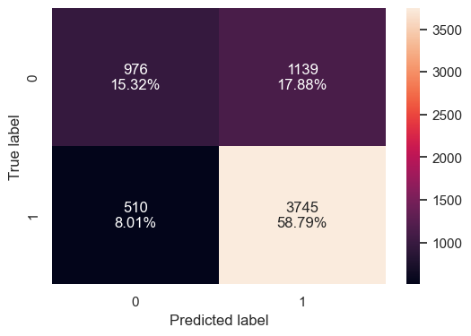

```python
# Evaluate the model on the test data
print("Test Performance:")
gbct_test_perf = model_performance_classification_sklearn(gbc_tuned, X_test, y_test)
display(gbct_test_perf)

# Plot the confusion matrix for the test set
confusion_matrix_sklearn(gbc_tuned, X_test, y_test)
```

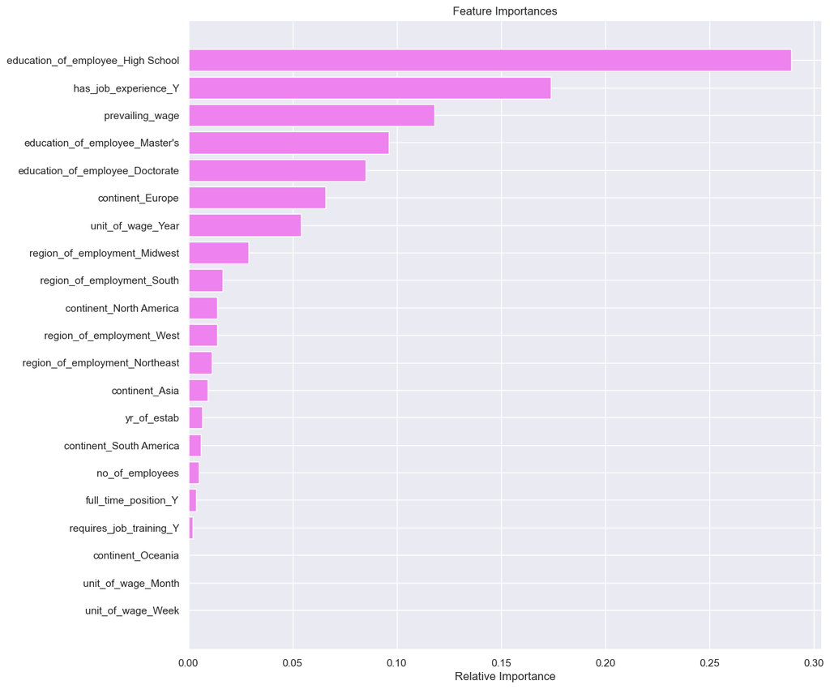

```python
importances = gbc_tuned.feature_importances_
indices = np.argsort(importances)
feature_names = list(X.columns)

plt.figure(figsize=(12, 12))
plt.title("Feature Importances")
plt.barh(range(len(indices)), importances[indices], color="violet", align="center")
plt.yticks(range(len(indices)), [feature_names[i] for i in indices])
plt.xlabel("Relative Importance")
plt.show()
```

**Observations:**